# KoLab R Study Week 1

March 28, 2019

## Week 1

## Rstudio Interface

## Windows

### Console

- prompt에 명령어를 입력하여 컴퓨터에게 작업을 시킴
- “>” 대기상태
- “+” 명령이 완전히 끝나지 않았음
- 작업 수행 중에는 오른쪽 위에 빨간 버튼이 생김
- 빨간 버튼이나 Esc키를 누르면 작업 강제 종료
- 위, 아래 화살표로 이전 명령을 간단하게 불러올 수 있음

## Windows

### Source

- 명령어 기록장 (for reproducibility)
- comments (주석) “#”: 컴퓨터에게 아무런 영향을 주지 않음
- **Tips.**
  - Ctrl + Enter: 한 줄 실행
  - Ctrl. + 1, Ctrl. + 2: 커서 이동

## Windows

### Environment

- 값들을 저장해 놓는 장소

### Etc.

- Files, Plots, Packages, Help, Viewer, etc.

## Options

- Tools -> Global Options
  - Appearance
    - Theme, Zoom, Font, **Editor Theme**, etc.
  - **Pane layout**
    - **Tips.** Source & Console 위치 조정

## 당장 활용할 수 있는 R

## Process of Analysis

- Data loading
- Data checking
- Statistical testing
- Plotting

## Data loading

```r
library(readxl)
Week1_example1 <- read_excel("Week1_example1.xlsx")
View(Week1_example1)
```

- 오잉?? library(readxl)이 뭐지?
- 오잉?? read_excel(“Week1_example1.xlsx”)이 뭐지?

## R 배경지식

### Packages

- 잘 정의된 형식의 R 함수, 데이터 및 컴파일된 코드의 모음
- 설치된 패키지는 library로 저장이 됨

```r
install.packages("sjPlot")
```

## R 배경지식

### Library

- 설치된 패키지를 불러드릴 땐 library(패키지명)
- library()는 Rstudio를 재시작할 때마다 로드해야 함

```r
library(sjPlot)
```

## R 배경지식

### 이름 바꾸기

- 변수(variable)의 이름이 너무 길다!
- 변수 이름 바꾸기

```r
# 불러올 때부터 짧은 이름으로 불러옴
w1 <- read_excel("Week1_example1.xlsx")

# 기존 데이터를 짧은 이름으로 바꿈
w1 <- Week1_example1
```

## Data checking

- 데이터 전체를 한 눈에 파악: str()
  - Observations
  - variables
  - num ??? chr ???

```r
str(w1)
```

```
## Classes 'tbl_df', 'tbl' and 'data.frame':    116 obs. of  19 variables:
##  $ ID          : num  1 2 3 4 5 6 7 8 9 10 ...
##  $ gender      : num  1 1 1 1 1 1 1 1 1 1 ...
##  $ 정서WB      : num  8 10 10 12 15 15 12 9 13 9 ...
##  $ 사회WB      : num  14 13 12 18 25 23 6 3 13 3 ...
##  $ 심리WB      : num  23 17 10 23 29 28 15 10 16 9 ...
##  $ 사회지능    : num  90 96 96 110 123 120 105 63 112 93 ...
##  $ 정서지능    : num  66 57 53 69 63 72 57 34 64 52 ...
##  $ 정신건강범주: chr  "플로리시" "중간수준의 정신건강" "중간수준의 정신건강" "중간수준의 정신건강" ...
##  $ 인지적공감  : num  58 50 60 60 55 62 55 47 67 52 ...
##  $ 정서적공감  : num  30 32 29 36 36 27 28 35 42 29 ...
##  $ 타인불신    : num  8 10 11 7 5 5 8 8 8 9 ...
##  $ 비도덕적조종: num  6 8 8 6 7 5 4 9 5 9 ...
##  $ 통제욕구    : num  7 7 6 4 7 6 5 3 7 5 ...
##  $ 지위욕구    : num  8 8 6 8 6 6 7 10 8 9 ...
##  $ 마키아벨리즘: num  29 33 31 25 25 22 24 30 28 32 ...
##  $ 우울        : num  6 7 11 7 1 0 5 14 10 13 ...
##  $ 불안애착    : num  49 41 59 37 38 25 64 84 51 47 ...
##  $ 회피애착    : num  57 57 83 35 44 40 63 70 67 71 ...
##  $ 관계만족도  : num  126 149 85 123 158 148 152 121 148 71 ...
```

## R 배경지식

### Function (함수)

- 프로그래밍의 핵심 요소
- 컴퓨터에게 행위를 시키는 역할 *(cf. 변수는 자료를 저장하는 역할)*
- 함수를 직접 작성할 수 있음
- 함수명()

## Data checking

- 하나의 변인의 특성을 파악 (연속 변인)

```r
summary(w1$관계만족도)
```

```
##    Min. 1st Qu.  Median    Mean 3rd Qu.    Max.
##    71.0   116.8   129.0   128.6   145.0   160.0
```

## Data checking

- 하나의 변인의 특성을 파악 (범주 변인)

```r
table(w1$정신건강범주)
```

```
##
##                     정신적 쇠약         정신적 쇠약 및 정신장애
##                               8                               2
##             중간수준의 정신건강 중간수준의 정신건강 및 정신장애
##                              80                               5
##                        플로리시
##                              21
```

## Statistical test

### basic statistics

```r
mean(w1$관계만족도); sd(w1$관계만족도)
```

```
## [1] 128.5948
```

```
## [1] 19.4793
```

```r
max(w1$관계만족도); min(w1$관계만족도)
```

```
## [1] 160
```

```
## [1] 71
```

## Statistical test

### t-test

```r
t.test(w1$사회지능, w1$정서지능)
```

```
##
##  Welch Two Sample t-test
##
## data:  w1$사회지능 and w1$정서지능
## t = 27.423, df = 183.39, p-value < 2.2e-16
## alternative hypothesis: true difference in means is not equal to 0
## 95 percent confidence interval:
##  41.11437 47.48908
## sample estimates:
## mean of x mean of y
## 100.98276  56.68103
```

## Statistical test

### Correlation test

```r
cor.test(w1$사회지능, w1$정서지능)
```

[output not shown]

## Correlation test

### sjPlot

- sjPlot: 상관표를 만드는 함수

```r
sjp.corr(w1)
```

```
## Error in stats::cor(data, method = corr.method): 'x' must be numeric
```

## Correlation test

### sjPlot

- **Quiz.** 왜 실행이 안 될까?

## R 배경지식

### Data type

- The five basic or atomic classes of obects (data type):
  - Logical
  - Numeric (real number)
  - Integer
  - Complex
  - Character

## R 배경지식

### Indexing

- 원하는 변인 사이의 상관을 확인하려면?
- 전체 데이터에서 원하는 데이터를 골라내야 한다!
- 전체 데이터에서 원하는 요소를 뽑아내는 방법:

  Indexing **(Very important)**

## R 배경지식

### Indexing

- data[ ] : data[ ] 안에 행 또는 행, 열을 숫자로 입력

```r
a <- c("언니네","아저씨","에베레스트")
a[1]; a[2]; a[3]
```

```
## [1] "언니네"
```

```
## [1] "아저씨"
```

```
## [1] "에베레스트"
```

- c() : 기본 데이터 묶음(vector)을 만드는 명령어

## R 배경지식

### Indexing

- [ ]
  - 요소가 3개인 데이터는 각각 [1], [2], [3]으로 indexing 가능
  - 여러 개의 요소를 한 번에 indexing할 수 있음: 1:2, 2:3, 1:3

```r
a[1:2]; a[2:3]; a[1:3]
```

```
## [1] "언니네" "아저씨"
```

```
## [1] "아저씨"     "에베레스트"
```

```
## [1] "언니네"     "아저씨"     "에베레스트"
```

## R 배경지식

### Indexing

- 우리의 데이터(w1)는 행과 열로 이루어져 있음
- w1[row, column]
  - 행 또는 열의 경우 Vector의 형태로 indexing 가능
    - w1[c(1, 2, 3), 1]
    - w1[1, c(1, 2, 3)]
    - w1[1, c(“ID”, “rs”)]

## R 배경지식

### Indexing

- data$변인명, data[row, column]
  - 전체 행 또는 전체 열을 indexing 할 경우 , 를 사용
    - data[1, 1] : 1행 1열의 값
    - data[1, ] : 1행의 전체 열
    - data[, 1] : 1열의 전체 행

## R 배경지식

### Indexing

```r
w1[1, 1];
```

```
## # A tibble: 1 x 1
##      ID
##   <dbl>
## 1     1
```

## R 배경지식

### Indexing

```r
w1[1, ]
```

```
## # A tibble: 1 x 19
##      ID gender 정서WB 사회WB 심리WB 사회지능 정서지능 정신건강범주 인지적공감
##   <dbl>  <dbl>  <dbl>  <dbl>  <dbl>    <dbl>    <dbl> <chr>             <dbl>
## 1     1      1      8     14     23       90       66 플로리시             58
## # ... with 10 more variables: 정서적공감 <dbl>, 타인불신 <dbl>,
## #   비도덕적조종 <dbl>, 통제욕구 <dbl>, 지위욕구 <dbl>, 마키아벨리즘 <dbl>,
## #   우울 <dbl>, 불안애착 <dbl>, 회피애착 <dbl>, 관계만족도 <dbl>
```

## R 배경지식

### Indexing

```r
w1[, 1]
```

```
## # A tibble: 116 x 1
##       ID
##    <dbl>
##  1     1
##  2     2
##  3     3
##  4     4
##  5     5
##  6     6
##  7     7
##  8     8
##  9     9
## 10    10
## # ... with 106 more rows
```

## R 배경지식

### Indexing

- $ 기호 사용
- data이름$variable이름[row]

```r
w1$ID
```

```
##   [1]   1   2   3   4   5   6   7   8   9  10  11  12  13  14  15  16  17  18
##  [19]  19  20  21  22  23  24  25  26  27  28  29  30  31  32  33  34  35  36
##  [37]  37  38  39  40  41  42  43  44  45  46  47  48  49  50  51  52  53  54
##  [55]  55  56  57  58  59  60  61  62  63  64  65  66  67  68  69  70  71  72
##  [73]  73  74  75  76  77  78  79  80  81  82  83  84  85  86  87  88  89  90
##  [91]  91  92  93  94  95  96  97  98  99 100 101 102 103 104 105 106 107 108
## [109] 109 110 111 112 113 114 115 116
```

```r
w1$gender
```

```
##   [1] 1 1 1 1 1 1 1 1 1 1 1 1 1 1 1 1 1 1 1 1 1 1 1 1 1 1 1 1 1 1 1 1 1 1 1 1 1
##  [38] 1 1 1 1 1 1 1 1 1 1 1 1 1 1 1 1 1 1 1 1 1 2 2 2 2 2 2 2 2 2 2 2 2 2 2 2 2
##  [75] 2 2 2 2 2 2 2 2 2 2 2 2 2 2 2 2 2 2 2 2 2 2 2 2 2 2 2 2 2 2 2 2 2 2 2 2 2
## [112] 2 2 2 2 2
```

## R 배경지식

### Indexing

- 1번째와 10번째 참가자의 ID

```r
w1[1, 1]; w1[10, 1]
```

```
## # A tibble: 1 x 1
##      ID
##   <dbl>
## 1     1
```

```
## # A tibble: 1 x 1
##      ID
##   <dbl>
## 1    10
```

```r
w1$ID[1]; w1$ID[10]
```

```
## [1] 1
```

```
## [1] 10
```

## R 배경지식

### Indexing

- **Quiz.** 11 ~ 13번째 참여자의 ID는?

## R 배경지식

### Indexing

- **Quiz.** 11 ~ 13번째 참여자의 ID는?

```r
w1[11:13, 1]; w1[11:13, "ID"]; w1$ID[11:13]
```

```
## # A tibble: 3 x 1
##      ID
##   <dbl>
## 1    11
## 2    12
## 3    13
```

```
## # A tibble: 3 x 1
##      ID
##   <dbl>
## 1    11
## 2    12
## 3    13
```

```
## [1] 11 12 13
```

## R 배경지식

### Indexing

- **Quiz.** 30번째 참여자의 사회지능은?

## R 배경지식

### Indexing

- **Quiz.** 30번째 참여자의 사회지능은?

```r
w1[30, 6]; w1[30, "사회지능"]; w1$사회지능[30]
```

```
## # A tibble: 1 x 1
##   사회지능
##      <dbl>
## 1       73
```

```
## # A tibble: 1 x 1
##   사회지능
##      <dbl>
## 1       73
```

```
## [1] 73
```

## R 배경지식

### Indexing

- **Quiz.** 16번째 참여자의 정서WB, 사회WB, 심리WB은?

## R 배경지식

### Indexing

- **Quiz.** 16번째 참여자의 정서WB, 사회WB, 심리WB은?

```r
w1[16, 3:5]; w1[16, c("정서WB", "사회WB", "심리WB")]
```

```
## # A tibble: 1 x 3
##   정서WB 사회WB 심리WB
##    <dbl>  <dbl>  <dbl>
## 1      9     15     23
```

```
## # A tibble: 1 x 3
##   정서WB 사회WB 심리WB
##    <dbl>  <dbl>  <dbl>
## 1      9     15     23
```

## R 배경지식

### Indexing

- **Quiz.** 15 ~ 30번째 참여자의 정서WB의 최대값과 최소값은?

## R 배경지식

### Indexing

- **Quiz.** 15 ~ 30번째 참여자의 정서WB의 최대값과 최소값은?

```r
max(w1[15:30, 3]); max(w1$정서WB[15:30])
```

```
## [1] 14
```

```
## [1] 14
```

```r
min(w1[15:30, 3]); min(w1$정서WB[15:30])
```

```
## [1] 3
```

```
## [1] 3
```

## R 배경지식

### Indexing

- **Quiz.** 전체 참여자의 관계만족도의 평균은?

## R 배경지식

### Indexing

- **Quiz.** 전체 참여자의 관계만족도의 평균은?

```r
mean(w1[, 19]); mean(w1$관계만족도)
```

```
## [1] NA
```

```
## [1] 128.5948
```

## R 배경지식

### Indexing

- 특정 변수를 제외하는 것은 마이너스 기호(-)를 사용

```r
# 1~112번째 참여자를 제외한 참여자의 데이터
w1[-(1:112), ]
```

```
## # A tibble: 4 x 19
##      ID gender 정서WB 사회WB 심리WB 사회지능 정서지능 정신건강범주 인지적공감
##   <dbl>  <dbl>  <dbl>  <dbl>  <dbl>    <dbl>    <dbl> <chr>             <dbl>
## 1   113      2     14     11     26      118       61 중간수준의 정신건강~         53
## 2   114      2      7      4      6      111       49 중간수준의 정신건강~         63
## 3   115      2      9      7      8       91       44 정신적 쇠약          50
## 4   116      2      9     11     16       92       55 중간수준의 정신건강~         51
## # ... with 10 more variables: 정서적공감 <dbl>, 타인불신 <dbl>,
## #   비도덕적조종 <dbl>, 통제욕구 <dbl>, 지위욕구 <dbl>, 마키아벨리즘 <dbl>,
## #   우울 <dbl>, 불안애착 <dbl>, 회피애착 <dbl>, 관계만족도 <dbl>
```

## R 배경지식

### Indexing

- 특정 변수를 제외하는 것은 마이너스 기호(-)를 사용

```r
# 정서WB을 제외한 전체 데이터
w1[, -3]
```

```
## # A tibble: 116 x 18
##       ID gender 사회WB 심리WB 사회지능 정서지능 정신건강범주 인지적공감
##    <dbl>  <dbl>  <dbl>  <dbl>    <dbl>    <dbl> <chr>             <dbl>
##  1     1      1     14     23       90       66 플로리시             58
##  2     2      1     13     17       96       57 중간수준의 정신건강~         50
##  3     3      1     12     10       96       53 중간수준의 정신건강~         60
##  4     4      1     18     23      110       69 중간수준의 정신건강~         60
##  5     5      1     25     29      123       63 중간수준의 정신건강~         55
##  6     6      1     23     28      120       72 중간수준의 정신건강~         62
##  7     7      1      6     15      105       57 중간수준의 정신건강~         55
##  8     8      1      3     10       63       34 플로리시             47
##  9     9      1     13     16      112       64 중간수준의 정신건강~         67
## 10    10      1      3      9       93       52 중간수준의 정신건강~         52
## # ... with 106 more rows, and 10 more variables: 정서적공감 <dbl>,
## #   타인불신 <dbl>, 비도덕적조종 <dbl>, 통제욕구 <dbl>, 지위욕구 <dbl>,
## #   마키아벨리즘 <dbl>, 우울 <dbl>, 불안애착 <dbl>, 회피애착 <dbl>,
## #   관계만족도 <dbl>
```

## R 배경지식

### Indexing

- **Quiz.** 2-17번째까지의 변수를 제외한 전체 데이터

## R 배경지식

### Indexing

- **Quiz.** 2-17번째까지의 변수를 제외한 전체 데이터

```r
w1[, -(2:17)]
```

```
## # A tibble: 116 x 3
##       ID 회피애착 관계만족도
##    <dbl>    <dbl>      <dbl>
##  1     1       57        126
##  2     2       57        149
##  3     3       83         85
##  4     4       35        123
##  5     5       44        158
##  6     6       40        148
##  7     7       63        152
##  8     8       70        121
##  9     9       67        148
## 10    10       71         71
## # ... with 106 more rows
```

## R 배경지식

### Indexing

- **Quiz.** 3, 5, 7번째 변수를 제외한 전체 데이터

## R 배경지식

### Indexing

- **Quiz.** 3, 5, 7번째 변수를 제외한 전체 데이터

```r
w1[, -c(3, 5, 7)]
```

```
## # A tibble: 116 x 16
##       ID gender 사회WB 사회지능 정신건강범주 인지적공감 정서적공감 타인불신
##    <dbl>  <dbl>  <dbl>    <dbl> <chr>             <dbl>      <dbl>    <dbl>
##  1     1      1     14       90 플로리시             58         30        8
##  2     2      1     13       96 중간수준의 정신건강~         50         32       10
##  3     3      1     12       96 중간수준의 정신건강~         60         29       11
##  4     4      1     18      110 중간수준의 정신건강~         60         36        7
##  5     5      1     25      123 중간수준의 정신건강~         55         36        5
##  6     6      1     23      120 중간수준의 정신건강~         62         27        5
##  7     7      1      6      105 중간수준의 정신건강~         55         28        8
##  8     8      1      3       63 플로리시             47         35        8
##  9     9      1     13      112 중간수준의 정신건강~         67         42        8
## 10    10      1      3       93 중간수준의 정신건강~         52         29        9
## # ... with 106 more rows, and 8 more variables: 비도덕적조종 <dbl>,
## #   통제욕구 <dbl>, 지위욕구 <dbl>, 마키아벨리즘 <dbl>, 우울 <dbl>,
## #   불안애착 <dbl>, 회피애착 <dbl>, 관계만족도 <dbl>
```

## R 배경지식

### Indexing

- **Quiz.** 우리가 Indexing 왜 하고 있었지?

## Correlation test

### sjPlot

- 원하는 변인들 사이의 상관 확인
- column 이름으로 지우는 방법은 조금 더 어려움

```r
sjp.corr(w1[,-c(1, 8)])
```

```
## Computing correlation using pearson-method with listwise-deletion...
```

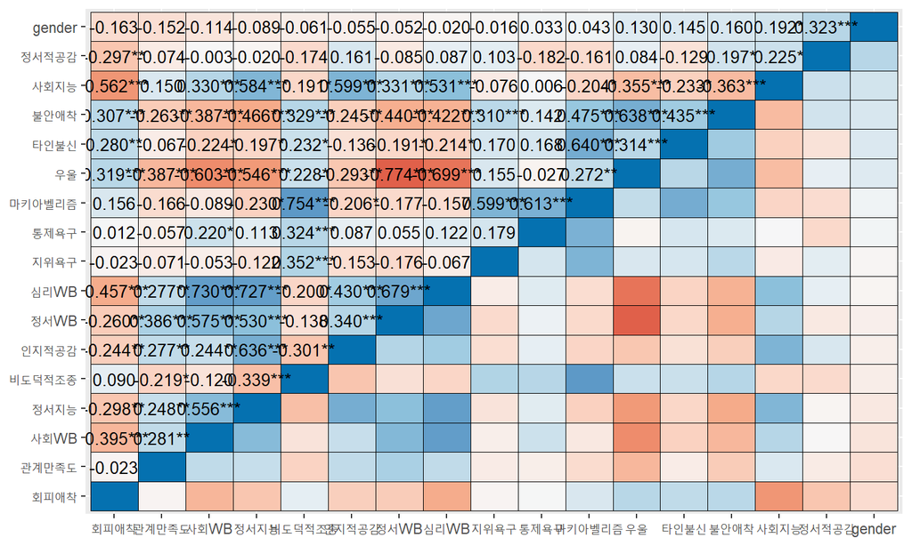

## Correlation test

### sjPlot

- **Quiz.** 정서지능, 마키아벨리즘, 관계만족도 사이의 상관

## Correlation test

### sjPlot

- **Quiz.** 정서지능, 마키아벨리즘, 관계만족도 사이의 상관
- 방법1

```r
sjp.corr(w1[, c(7, 15,19)])
```

```
## Computing correlation using pearson-method with listwise-deletion...
```

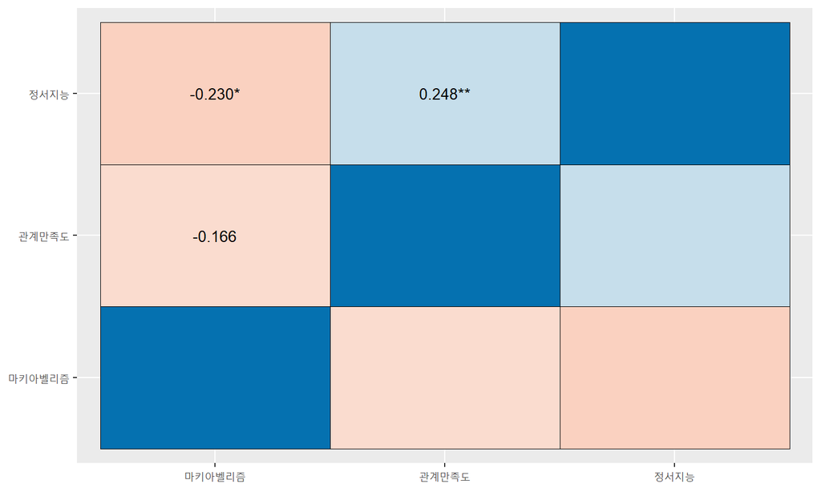

## Correlation test

### sjPlot

- **Quiz.** 정서지능, 마키아벨리즘, 관계만족도 사이의 상관
- 방법2

```r
sjp.corr(w1[, c("정서지능", "마키아벨리즘", "우울", "관계만족도")])
```

```
## Computing correlation using pearson-method with listwise-deletion...
```

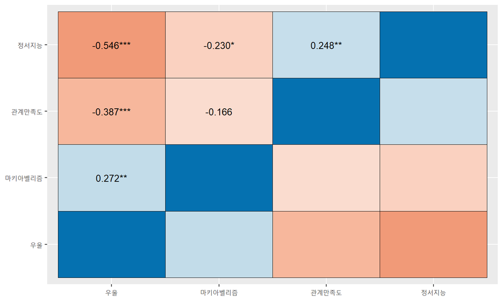

## Correlation test

### sjPlot

- **Quiz.** 정서지능, 마키아벨리즘, 관계만족도 사이의 상관
- 방법3

```r
var <- c("정서지능", "마키아벨리즘", "우울", "관계만족도")
sjp.corr(w1[, var])
```

```
## Computing correlation using pearson-method with listwise-deletion...
```

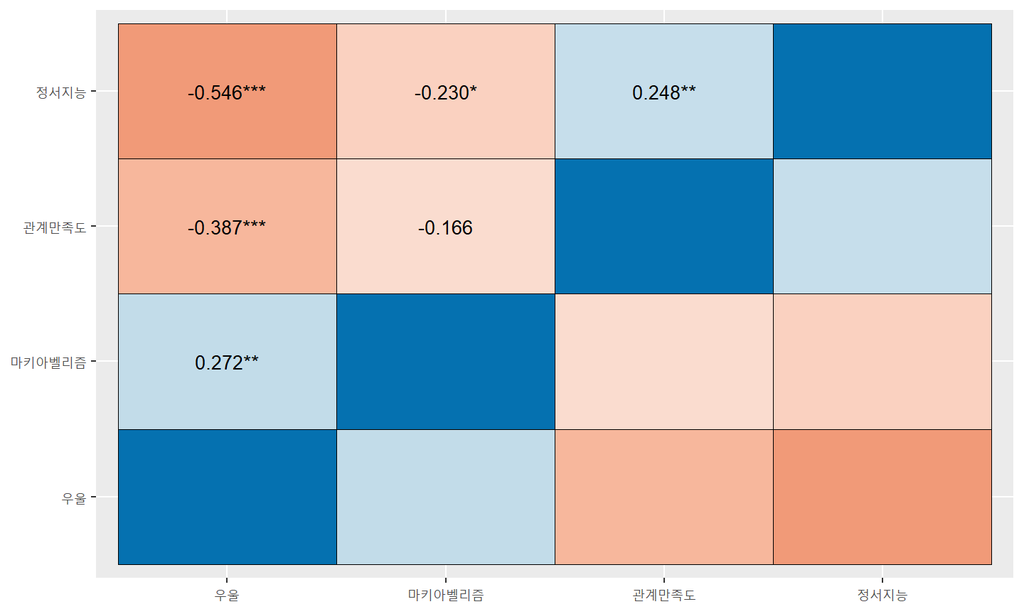

## R 배경지식

### Objects 활용하기

- 반복적으로 사용하는 명령어, 범위, 숫자 등을 하나의 object로 정의

```r
par <- c(1, 2, 3, 6, 78, 101)
mean(w1$정서WB[par]);mean(w1$사회WB[par]);mean(w1$심리WB[par])
```

```
## [1] 10.33333
```

```
## [1] 14.5
```

```
## [1] 21.33333
```

## R 배경지식

### Objects 활용하기

- **Quiz.** 2, 4, 6, 11, 20 번째 참여자의 정서WB, 사회WB, 심리WB의 평균 구하기

## R 배경지식

### Objects 활용하기

- **Quiz.** 2, 4, 6, 11, 20 번째 참여자의 정서WB, 사회WB, 심리WB의 평균 구하기

```r
par <- c(2, 4, 6, 11, 20)
mean(w1$정서WB[par]);mean(w1$사회WB[par]);mean(w1$심리WB[par])
```

```
## [1] 10.4
```

```
## [1] 14.6
```

```
## [1] 18.6
```

## Correlation test

### sjPlot

- 논문 보고 형태

```r
sjt.corr(
    w1[, var])
```

[output not shown]

## Correlation test

### sjPlot

- 그런데, 논문에서 보던 것과 모양이 다른데?
- 아래 부분만 나오게 할 수는 없을까?

## Correlation test

### sjPlot

- **argument**

```r
sjt.corr(
    w1[, var],
    triangle = "lower"
)
```

[output not shown]

## R 배경지식

### Argument

- 함수를 더욱 미세하게 조정
- 다양한 세부 옵션들 조정
- 함수별 argument를 확인하고 싶으면??
  - help 기능 사용: ?함수명 ex) ?sjt.corr
  - 구글링

## Correlation test

### sjPlot

- 워드로 저장할 수 없을까?

```r
sjt.corr(
    w1[, var],
    triangle = "lower",
    file = "corr.test.doc"
)
```

[output not shown]

- 저장한 워드파일은 어디에 있을까?

## R 배경지식_(7)

### Directory

- 컴퓨터 내에서 파일이 저장되는 구조
- OS 마다 다름
- Directory의 구조를 알아야 자료를 불러오고 저장할 수 있음
- ex. “C:/Users/a0728/Dropbox/study”

## R 배경지식_(7)

### Working directory (작업 공간)

- R에서 작업이 일어나는 공간
- setwd(): Working directory 설정
  - GUI:
  - setwd(“C:/Users/a0728/Dropbox/study”)
- getwd(): 작업 공간 확인

```r
getwd()
```

```
## [1] "C:/Users/Kibum Moon/Dropbox/blog/Rstudy"
```

## R 배경지식_(7)

### Path

- 절대 경로
  - 처음부터 찾아가기
- 상대 경로
  - Working directory로부터의 경로
  - ./ : Working directory까지의 경로
    - ex. “./폴더이름/파일이름”
  - ../ : Working directory 상위 폴더로 이동
    - ex. “../폴더이름/파일이름”

## R 배경지식_(7)

### File extensions

- 컴퓨터 파일의 이름에서 파일의 종류와 그 역할을 표시하기 위해 사용하는 부분
- csv, xls, xlsx, jpg, png, etc.

## Correlation test

### sjPlot

```r
sjt.corr(
    w1[, var],
    triangle = "lower",
    file = "corr.test.doc"
)
```

[output not shown]

## Plotting

### histogram

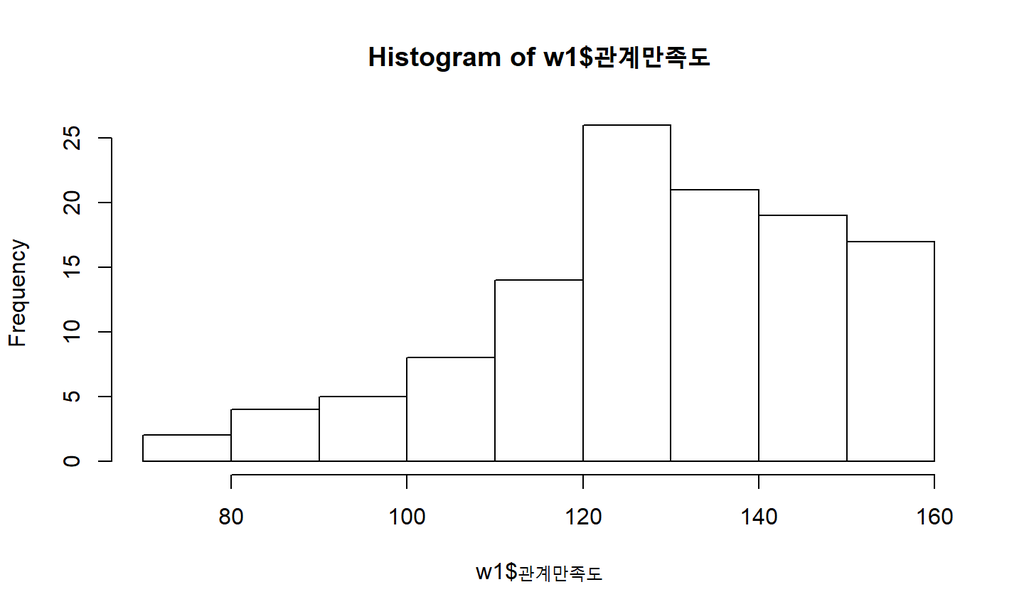

```r
hist(w1$관계만족도)
```

## Plotting

### Scatter plot

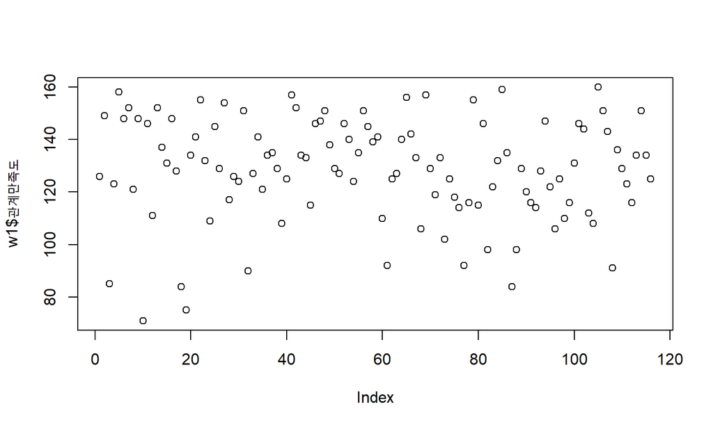

```r
plot(w1$관계만족도)
```

## Plotting

### Scatter plot

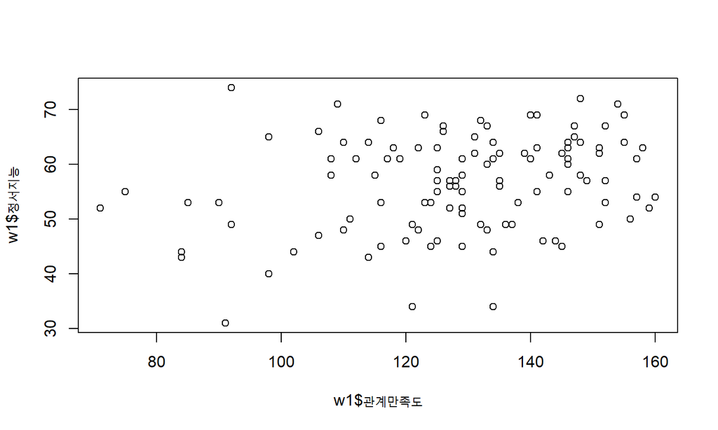

```r
plot(w1$관계만족도, w1$정서지능)
```